# Trabajo Individual

# Presentación de la propuesta para investigación

## SECCIÓN A: Investigación Original

Mi trabajo es un intento por replantear la investigación de Kiara Castaman (2017) sobre el cambio cultural en el Perú, por ello, en esta sección realizaré un resumen de *“Tradición y postmaterialismo en el Perú (1996-2012): Análisis a partir de la Encuesta Mundial de Valores”*

*Resumen de la investigación*

El trabajo de Kiara Castaman tiene como principal objetivo explicar los cambios y permanencias de los valores sociales de los peruanos mediante al análisis de cuatro olas de la Encuesta Mundial de Valores entre 1996 y 2012. Esto mediante la utilización de la teoría del cambio cultural propuesta por Ronald Inglehart. Siguiendo las ideas del autor se realizó el estudio del cambio cultural desde dos dimensiones: la de los valores tradicionales o racional-seculares y la dimensión de los valores materialistas (valores orientados hacia la seguridad física/material) o post-materialistas (valores orientados al respeto y la autorreflexión). La presentación de la investigación se dio través de dos indicadores para construir la variable de nivel socioeconómico: las diferencias según nivel de ingresos y el nivel educativo. Se concluyó en el trabajo que el país no habría experimentado un cambio importante a nivel cultural, a pesar de que se han manifestado grandes transformaciones estructurales durante los últimos veinte años.

## SECCIÓN B: Investigación propia

Presentación del tema y modificaciones a seguir para el desarrollo de mi trabajo.

### 1. Pregunta de investigación:

*¿Cuál es la influencia del tradicionalismo el perfil de los valores sociales de los peruanos a partir de la teoría del cambio cultural de Inglehart en el 2018?*

### 2. Justifación e interés:

Como menciona Castaman (2017) el Perú ha experimentado transformaciones a nivel económico y político. Con respecto al primero la tendencia al crecimiento del PBI observado por la autora durante el 2001 y 2011 parece mantener esa tendencia, por lo menos en los años previos a la crisis sanitaria a causa de la COVID19. Asimismo, hemos atravesado por elecciones democráticas durante 20 años desde el final de la dictadura de Alberto Fujimori. Dentro de ese patrón de estabilidad a nivel macro se había podido observar una considerable reducción de la pobreza dentro de los años señalados por la autora según datos de la ENAHO, esto, evidentemente, antes de la crisis ya mencionada. Lo cual evidencia la fragilidad del sistema económico del Perú, pero ese es un tema que debe tratarse en otra investigación. Mi trabajo se centrará en denotar las diferencias de género dentro de las mejoras mencionadas mediante el análisis de los cambios culturales de la teoría de Inglehart en las mismas dimensiones con las que ella trabaja: la transición del tradicionalismo a la racionalidad-secularización y del materialismo al post-materialismo.

Guerra (2018) concluye en su trabajo que en el Perú diversas normas han permitido que las mujeres tengan acceso a la educación, a la asistencia médica, trabajo y consideración dentro de la toma de decisiones políticas y económicas. Asimismo, menciona que estos cambios han sido generados tanto desde actores formales, como las instituciones estatales, e informales como los sindicatos, gremios y grupos que buscan un objetivo común: beneficiarse de las políticas públicas. En ese sentido, me interesa averiguar si estas mejoras en la situación de las mujeres, posiblemente relacionadas a las condiciones macro mencionadas al inicio, pueden observarse dentro de un cambio cultural. Si bien las políticas de género han mejorado el estilo de vida de las mujeres y sus posibilidades para acceder a mayores grados de instrucción en general, es importante observar si esto ha implicado un cambio cultural en el que hombres y mujeres tengan o no los mismos valores a evaluar. Asimismo, es importante recordar que en un país con diferencias significativas en la distribución de los ingresos ver las diferencias entre las mujeres con mayores grados de instrucción y aquellas con menores grados. Esto con la finalidad de observar la transición del Perú a una sociedad moderna, a nivel de los valores sociales, desde las diferencias o similitudes entre los géneros, así como las diferencias tomando en cuenta los grados de instrucción comparativamente dentro de un mismo género.

Finalmente, el cambio de la variable nivel de ingresos por clase social se basa en que si bien es posible determinar la “clase objetiva” de un grupo de invidivuos mediante el cálculo de sus ingresos, es importante revisar como la clase subjetiva puede relacionarse con la priorización de ciertos objetivos o valores específicos. Es decir, revisar la autopercepción de los sujetos dentro de una clase social puede arrojar luces sobre la influencia en los patrones de pensamiento de estos comparten debido a esta percepción de pertenecia.

#### Replanteamiento del interés:

Luego de revisar los principales resultados de la investigación considero que fue algo ambiciosa mi visión de evaluar los cambios a nivel de género sin considerar primero si, en efecto, existía alguna relación entre el tradicionalismo y el postmaterialismo, por ello, dentro de la discusión sobre los resultados haré mayor énfasis en esa relación, ya que como se verá más adelante es difícil afirmar que existen diferencias a nivel de género por varios motivos, entre metodológicos y cuestiones propias de la muestra.

### 3. Breve revisión de la literatura

Dentro de su investigación Castman (2017) resalta que los resultados de la EMV han sido utilizados de manera diversa para distintos tipos de investigaciones con, evidentemente, distintos enfoques temporales, metodológicos y temáticos para analizar las tendencias culturales de países desarrollados, en crecimiento, o que atraviesan o han atravesado crisis. El uso de la EMV para el estudio de los patrones culturales se ha realizado a propósito de que la Teoría sobre el Proceso de Cambio Cultural de Inglehart es la base teórica de la mencionada encuesta; pero, también se ha hecho un esfuerzo por validar sus premisas en diversos contextos. Dentro de los estudios que la autora señala se encuentra el de Diez Nicolás (2011) quien concluyó que el entorno social marcado por una inestabilidad o estabilidad económica, así como una confianza o desconfianza interpersonal conlleva un cierto alejamiento o acercamiento a los valores post-materialistas. Su estudio, asimismo, integró por primera vez países de Latinoamérica, concretamente a Chile y Argentina dentro del análisis, cuestión innovadora, pues los análisis sobre post-materialismo se realizaron inicialmente en países desarrollados.

Aunque ese no ha sido el único intento por recopilar información y estudios sobre la región, ya que en 2013 el Centro de Estudios Sociales y de Opinión Pública (CESOP) realizó una compilación de varias investigaciones relacionadas al cambio de los calores culturales en América Latina recogiendo información sobre el capital social, la secularización, la felicidad, etc. Así, dentro de dicha compilación se encuentra la investigación realizada por Catalina Romero (2008) que se centra en el análisis comparativo sobre la religiosidad y su relación con la economía, la política y la cultura en países Latinoamericanos a partir de la EMV. La autora concluye que la religiosidad ha incrementado dentro de los países de América Latina, en relación a la importancia de Dios y la identidad religiosa, pero también ha atravesado cambios, de manera que ya no es posible asociarla a los valores tradicionales y autoritarios, sino más bien a la autoexpresión y autonomía. En ese sentido, señala Romero que es importante discutir que la religión y los propios procesos de cambio social se deben entender desde su relación con los actores e instituciones políticas, en lugar de considerar que existen procesos “inevitables” de secularización. Desde la misma autora, en colaboración con David Sulmont en el 2000 se aterrizó una investigación sobre los valores en el Perú y se usa por primera vez el indicador de post-materialismo, aunque de manera limitada pues solo se tenían registros para 1996.

Fuera de dichos estudios, el cambio cultural se ha explorado desde otras perspectivas tomando en cuenta los datos de la EMV y la teoría de Inglehart. En primer lugar, está la investigación de Abellán (2019) que se cuestionó acerca de la importancia de las problemáticas rurales, como la escasez de estructuras productivas y la pérdida del peso relativo de la agricultura como sector económico clave, dentro de las propuestas políticas de los partidos de España en 2019. Esto en relación a una vinculación teórica entre los valores materialistas y postmaterialistas de Inglehart y el paso del productivismo al post-productivismo en las zonas rurales. Es decir, el autor observó la relación entre la importancia que los partidos políticos le otorgan a la producción industrial y los valores post-materialistas que se pueden propagar desde la atención a lo rural, por ejemplo, el ecologismo, la justicia ambiental, la sostenibilidad, etc. esto para observar si existe realmente una transición al post-productivismo. Abellán concluyó que tanto partidos de derecha como de izquierda tienen propuestas desarrollistas en relación a la producción agrícola, pero no con un enfoque en lo rural y sus valores. Los partidos tradicionalmente identificados como izquierda se les da más importancia a los valores progresistas, mientras que los partidos de derecha mantienen la promulgación de valores tradicionales.

Por otro lado, un estudio que toma una perspectiva distinta e innovadora es el realizado por Rendueles (2016) acerca del impacto de la tecnología como un vector político que transforma las condiciones del ejercicio de la democracia. Así, desarrolla el concepto de ciudadanía digital, señala que esta apunta a poder revertir la desafección por la política que genera la tecnología en las sociedades de masas, esto porque el autor señala que la tecnología de la comunicación no solo puede transformar el bagaje político precedente, sino que puede incluir cambios en las condiciones y formas de legitimización dentro de la intervención política. Asimismo, señala que el uso de tecnología puede generar una transformación en los valores post-materialistas entendidos como preponderantes en contextos de individualismo y mercantilización de las sociedades occidentales. Randueles concluye que la tecnología de la comunicación, en concreto las redes sociales, podrían ser una especie de mercado donde la organización emerge de manera natural y sin norma finalistas; en ese sentido, aunque presenta limitaciones técnicas para al ejercicio de una democracia participativa no se puede asociar directamente su emergencia con la incrementación de un individualismo que debilite la importancia de la participación conjunta en la democracia.

Finalmente, se puede señalar la investigación de Ribeiro en (2007) en la que intenta poner a prueba las tesis de Inglehart sobre la búsqueda de autoexpresión que engendra demandas mediante formas de participación autónoma y activa de la ciudadanía como un rasgo de la evolución social hacia el postmaterialismo. De manera concreta, el autor trata de probar si existe una asociación entre el postmaterialismo (un cambio de los valores culturales) y una cultura participativa. Usando las encuestas de 1991 y 1997 realizadas en Brasil para su análisis llegó a la conclusión de que esa asociación no se ha comprobado en Brasil. Aunque se encontró que los individuos más postmaterialistas suelen ser los que conversan más sobre política y le atribuyen mayor importancia en su vida, no es posible asociarla esa relación a un incremento en la participación política tradicional, pero sí con algunas formas de acción política no convencionales.

### 4. Metodología:

1. Fuente: Encuesta mundial de valores
2. Año elegido/ola: 2018
3. Conjunto muestral: 1400 peruanos mayores de edad (muestra representativa)

### 5. Variables e indicadores:

#### 5.1. Variable dependiente:

Antes de presentar la variable dependiente, el postmaterialismo, es muy importante explicar los cambios que tuvo el indicador mientras se desarrolló el trabajo. El postmaterialismo dentro de la investigación tiene dos indicadores, el primer indicador, al cual nombré *inclusivo*, está contruido a partir de la conjunción del “Indice de materialismo”, en tanto objetivos que apuntan a la seguridad física y la autoexpresión, y “variables adicionales” que serán especificadas pronto. El segundo indicador que recibió el nombre de *exclusivo* el cual solo está construido a partir de “Indice de materialismo” (objetivos). A continuación se explica más esta división:

**Post-materialismo (inclusivo)** :

- Índice de materialismo-postmaterialismo de 4 ítems

[las siguientes son las variables adicionales]

- El sentimiento de felicidad que manifiestan los encuestados
- La justificación de la homosexualidad
- Importancia de la democracia
- La confianza interpersonal entre peruanos

**Post-materialismo (exclusivo)** :

- Índice de materialismo-postmaterialismo de 4 ítems

[Cada ítem dentro está compuesto por una caja de preguntas, estás plantean ciertos objetivos que deberían ser prioritarios en el Perú, por ejemplo, “luchar contra la delincuencia”, “mayor participación comunitaria”, entre otros. Se le indica al encuestado que escoja dos objetivos, el primero más prioritario y el segundo más prioritario, por cada caja de preguntas. Es a partir de la elencción de ciertos objetivos por sobre otros que se determina si la persona puede considerarse materialista o postmaterialista]

Ambos indicadores se utilizan en diferentes modelos para observar las cambios en la correlación que una composición diferente puede ocasionar.

*Materialistas*: Priorizar la seguridad física y material antes que la autoexpresión, poco felices, consideren la homosexualidad como injustificable, no consideren firmar peticiones y con desconfianza.

*Post-materialismo*: Lo contrario a lo anterior

#### 5.2. Variable independiente:

1. **Tradicionalismo** : Valores tradicionales y los racionales-seculares:
- Importancia de Dios en la vida
- Índice de autonomía
- Justificación del aborto
- Sentimiento de orgullo nacional
- Mayor respeto por la autoridad

*Tradicionales* : Más inclinados hacia la crianza en fe y obediencia, así como un fuerte sentimiento nacional que conlleva posteriormente a un mayor respeto hacia la autoridad.

*Secular-racional*: inclinados hacia un alto índice de autonomía, críticos con la autoridad, con poca orientación a Dios, etc.

2. **Clase social** : Se opta por la clase social subjetiva y no por la variable nivel socioeconómico. La variable presenta las categorías de clase social alta, media-alta, trabajadora/obrera, media baja y baja. Sin embargo, por cuestiones prácticas se fusionaran categorías de modo que la variable contenga solo 3 categorías: alta, trabajadora y baja
3. **Nivel educativo** : El nivel educativo contiene 11 categorías, sin instrucción, primaria incompleta, primaria completa, secundaria incompleta, secundaria completa, superior técnica, completa e incompleta, superior universitaria, completa e incompleta, licenciatura, maestría y doctorado. Sin embargo, por las mismas razones explicadas para la anterior variable, se usarán 5 categoríaas: Incompleta, primaria completa, secundaria completa, superior completa, maestríaa/doctorado.
4. **Sexo** : Categoría dicotómica de hombre y mujer

### 6. Limitaciones:

Los datos que ofrece la base de datos son comparativamente menores en cuanto al tamaño de la muestra, pues esta contiene solo 1400 respuestas registradas, mientras que bases de datos como la EHAHO, LAPOP, etc. presentan alrededor de 10000 casos. Adicionalmente, existen varias categorías en diversos indicadores que se encuentran sobre o sub representadas; sin embargo, para reducir el impacto de dicho sesgo se reagruparon algunas categorías, como se explicó en la sección anterior.Cabe resaltar que se regresará a discutir esta cuestión al final del trabajo. Finalmente, mi trabajo no busca realizar una comparación y no toma en cuenta el efecto de la pandemia en el cambio cultural en el Perú, uno de los países más golpeados por el covid, cuestión que podría ser interesante realizar, ya que como señala la literatura periodos de crisis pueden incrementar la cantidad de personas creyentes en una sociedad, así como la cantidad de personas que incrementan su confianza en cierto tipo de instituciones o grupos de personas (como el sector salud en este caso).

### 7. Bases de datos

Para detalles sobre la base de datos hacer click [aquí](https://www.worldvaluessurvey.org/WVSDocumentationWV7.jsp).

En la parte superior derecha de la página se puede escoger el país, en el caso del Perú el último año registrado es en el 2018 de la 7 ola.

## SECCIÓN C: Gráficos descriptivos

### Tablas y gráficos descriptivos de las variables independientes

Variable Sexo

| Sexo | Frecuencia |
| --- | --- |
| Hombre | 50.84 |
| Mujer | 49.16 |

Variable Clase Social

| Clase | Frecuencia |
| --- | --- |
| Alta | 17.90 |
| Trabajadora | 52.18 |
| Baja | 29.92 |

Variable Nivel Educativo

| Nivel Educativo | Frecuencia |
| --- | --- |
| Sin instruccion | 42.52 |
| Primaria completa | 41.09 |
| Secundaria Completa | 12.52 |
| Superior Completa | 3.45 |
| Maestria/Doctorado | 0.42 |

.

Acerca de esta sección se puede observar de manera general que existe una proporción similar de participación de hombres y mujeres en la encuesta. Se identifica una clara mayoría de personas encuestadas que no tienen ningún grado de instrucción o solo han concluido la primaria (sus porcentajes conjuntos alcanzan casi un 83%). Asimismo, la proporción de personas que ha concluido el colegio (secundaria completa) no supera el 14%. Los porcentajes de educación superior completa, técnica o universitaria, son considerablemente reducidos, más aún los porcentajes de personas con altos grados de instrucción. Por otro lado, se puede identificar una alta concentración de personas que se autoperciben como parte de trabajadora.

#### Tradicionalismo

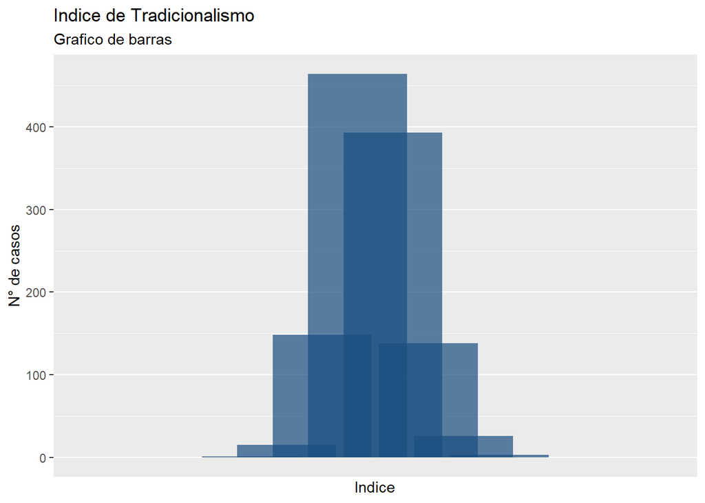

**Estadisticos descriptivos**

| Statistic | N | Mean | St. Dev. | Min | Pctl(25) | Pctl(75) | Max |
| --- | --- | --- | --- | --- | --- | --- | --- |
| Tradicionalismo | 1,188 | 0.498 | 0.141 | 0.000 | 0.429 | 0.571 | 1.000 |

.

Acerca del índice de tradicionalismo se observa un que el promedio de esta variable se encuentra cerca de los valores centrales, con una casi impercetible inclinación hacia el mayor tradicionalismo.

### Gráficos y tablas cruzadas de las variables independientes

#### Tabla y grafico de nivel educativo, segun sexo

Nivel educativo, según sexo

|  | Hombre | Mujer |
| --- | --- | --- |
| Sin instruccion | 44.30 | 40.68 |
| Primaria completa | 39.50 | 42.74 |
| Secundaria Completa | 12.23 | 12.82 |
| Superior Completa | 3.47 | 3.42 |
| Maestria/Doctorado | 0.50 | 0.34 |

.

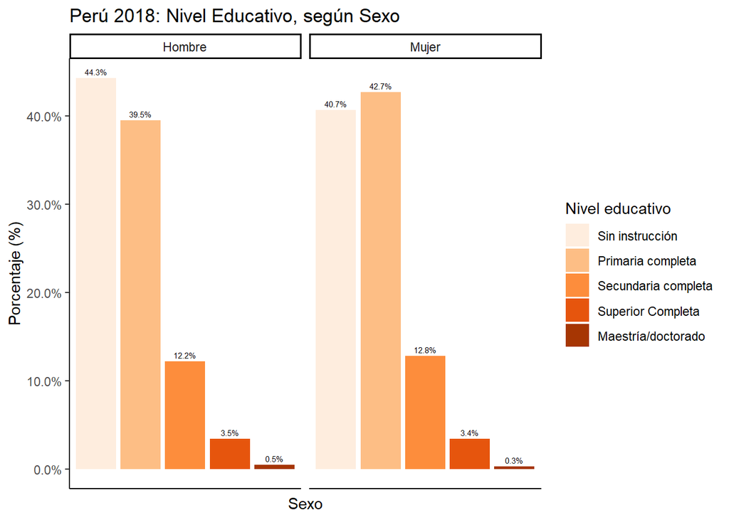

.

Sobre este primer cruce entre variables independientes se observa que en ambos sexos existe una gran mayoría de personas que no han recibido ningún tipo de educación formal, a nivel escolar, o que no concluyeton la primaria. Sin embargo existe una cantidad ligeramente mayor de hombres sin instrucción, al igual que una ligera mayoría de mujeres que poseen primaria completa. En las demás categorías no se obervan diferencias que sean remarcables.

.

#### Tabla y grafico de la clase social, según sexo

Clase Social, según sexo

|  | Hombre | Mujer |
| --- | --- | --- |
| Alta | 17.36 | 18.46 |
| Trabajadora | 51.90 | 52.48 |
| Baja | 30.74 | 29.06 |

.

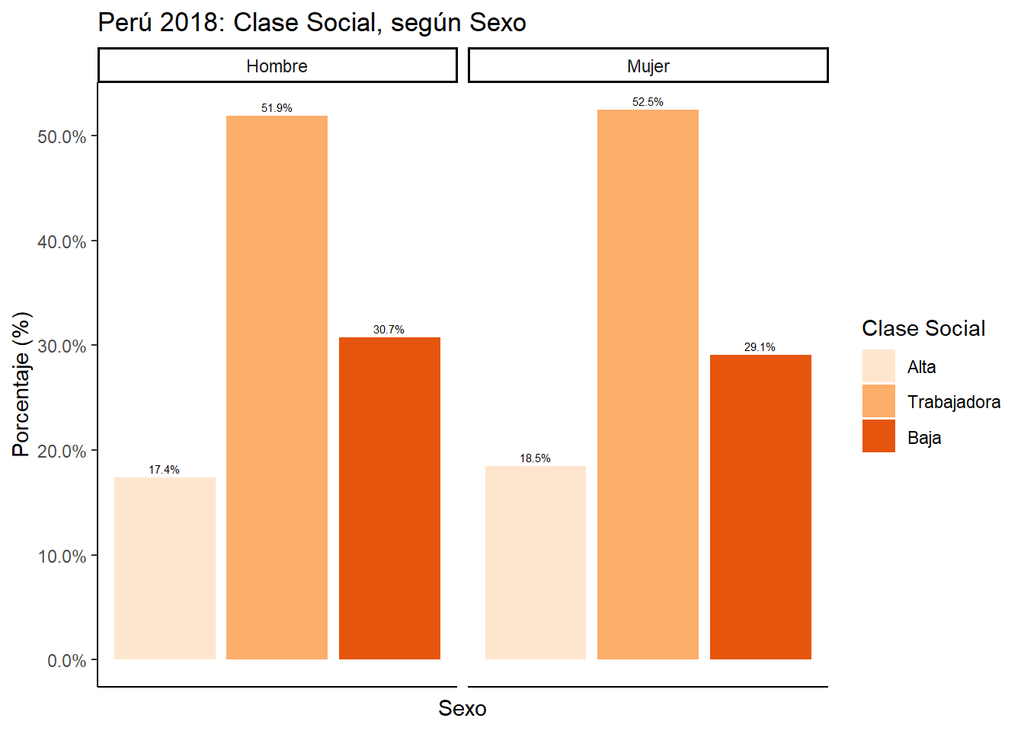

.

Acerca de este segundo cruce se observa que existe una distribución muy similar de mujeres y hombres en las diferentes clases sociales. Cabe resaltar, nuevamente que la clase trabajadora es la que tiene mayor representitividad y que no se diferencia de manera significativa entre los sexos.

.

#### Tabla del Nivel Educaivo, según la clase social

Nivel educativo, según clase social

|  | Alta | Trabajadora | Baja |
| --- | --- | --- | --- |
| Sin instruccion | 52.11 | 39.45 | 42.13 |
| Primaria completa | 40.38 | 41.71 | 40.45 |
| Secundaria Completa | 7.51 | 14.17 | 12.64 |
| Superior Completa | 0.00 | 4.19 | 4.21 |
| Maestria/Doctorado | 0.00 | 0.48 | 0.56 |

.

Sobre este cruce, debido a las propociones observadas y a la cantidad de categorías por variable se optó por hacer solo una tabla cruzada. Ahora bien dentro de lo que se puede observar existen relaciones constraintuitivas e incluso contra teóricas. Por ejemplo, el 52% de las personas de clase alta no poseen ningún grado de instrucción o solo con primaria completa (la suma de ambos porcentajes es de casi el 92%), mientras que solo un 7% posee secundaria completa. Dentro de las siguientes clases, trabajadora y baja, se observa la misma situación, sin embago, hay un mayor porcentaje de personas de clase trabajadora que tienen secundaria completa e incluso superior completa, porcentaje que incluso es un poco mayor en la clase baja. La proporción de personas sin educación que son de clase baja es más “coherente”, del mismo modo para la clase trabajadoro; esto en tanto pueden existir menos opotunidades de trabajo o ascenso social si los niveles de educación son menores. Sin embargo, la primera relación descrita, clase alta sin eduación es peculiar y puede describir algunos de los problemas que tiene la muestra elegida, cuestión que será discutida a mayor profundidad más adelante.

#### Gráfico y estadísticos descriptivos del tradicionalismo, segun sexo

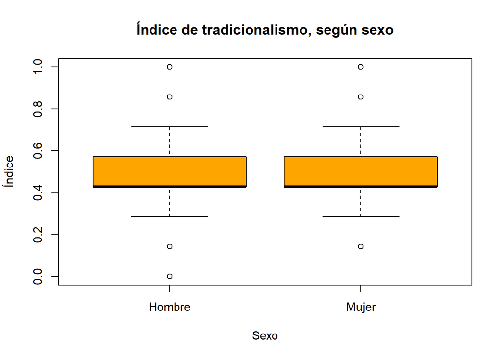

Tradicionalismo segú sexo

| Sex | Media | Minimo | Maximo | Diferencia | Desviacion |
| --- | --- | --- | --- | --- | --- |
| Hombre | 0.49 | 0.00 | 1 | 1.00 | 0.14 |
| Mujer | 0.50 | 0.14 | 1 | 0.86 | 0.14 |

.

.

#### Gráfico y estadísticos descriptivos del tradicionalismo, segun clase social

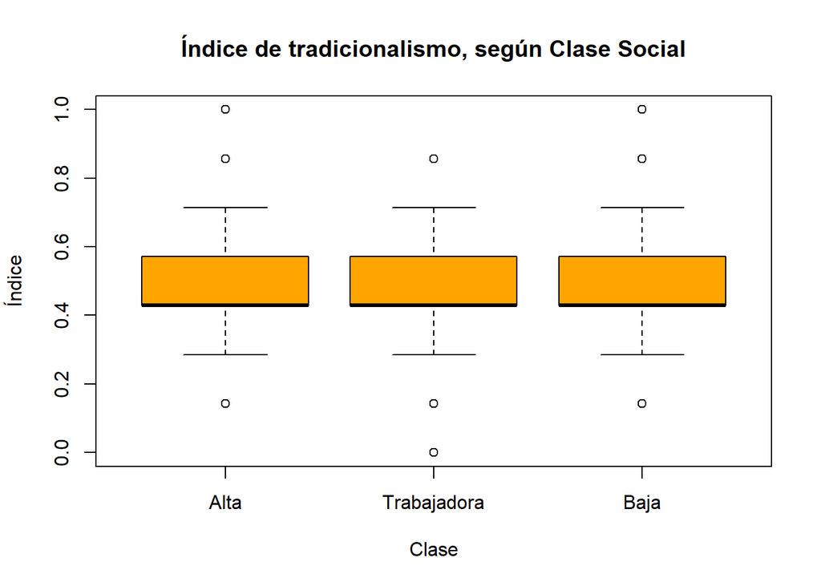

Tradicionalismo segú clase social

| Clases | Media | Minimo | Maximo | Diferencia | Desviacion |
| --- | --- | --- | --- | --- | --- |
| Trabajadora | 0.496 | 0.000 | 0.857 | 0.857 | 0.139 |
| Baja | 0.500 | 0.143 | 1.000 | 0.857 | 0.147 |
| Alta | 0.500 | 0.143 | 1.000 | 0.857 | 0.139 |

.

Sobre la relación entre las clases sociales y el tradicionalismo se puede observar que no existen diferencias significativas entre los tres grupos. Una diferencia que se podría resaltar, aunque no es significativa, es que el valor máximo alcanzado por los de clase trabajadora no es 1 (menos tradicionalistas), sino 0.87, cuestión que es diferentes en las demás clases. Del mismo modo sucede con el mínimo (más tradicionalista), en el que este grupo es el único que alcanza el valor mínimo extremo.

.

#### Gráfico y estadísticos descriptivos del tradicionalismo, segun nivel educativo

[figure not shown]

Tradicionalismo según nivel educativo

| NEDU | Media | Minimo | Maximo | Diferencia | Desviacion |
| --- | --- | --- | --- | --- | --- |
| Maestria/Doctorado | 0.429 | 0.286 | 0.571 | 0.286 | 0.101 |
| Superior Completa | 0.467 | 0.143 | 0.714 | 0.571 | 0.132 |
| Secundaria Completa | 0.481 | 0.143 | 0.857 | 0.714 | 0.130 |
| Primaria completa | 0.497 | 0.143 | 1.000 | 0.857 | 0.136 |
| Sin instruccion | 0.507 | 0.000 | 1.000 | 1.000 | 0.150 |

.

Sobre este último cruce se puede observar que las diferencias entre los niveles educativos son relativamente más notorias, aunque de ningún modo significativas. Así, las personas con maestría/doctorado tienen el mayor grado de tradicionalismo, en tanto su promedio es el más cercano a cero y el valor máximo que alcanzaron fue de 0.57. En los demás grupos de observa una lógica descendente en la que a menor grado de instrucción el promedio se incrementa, es decir, hay menos tradicionalismo, cuestión nuevamente anti-intuitiva. Cabe resaltar que ningún grupo sobrepasa realmente el valor medio de tradicionalismo y todos se ubicarían en el espectro más “tradicional” del índice.

**Discusión general sobre los estadísticos descriptivos**

La información señalada hasta ahora indica que la población encuestada se caracteriza por tener poco grado de instrucción y percibirse como parte de la clase trabajadora/baja, además, existen similitudes importantes en cuanto al perfil diferenciado por sexo, con algunas diferencias, pero que no son significativas (son decimáles). Es relevante tener en cuenta lo mencionado, porque podría tener un efecto en los comportamientos/ideales culturales de la población encuestada, es decir en el grado de postmaterialismo. Sin embargo, si la muestra recogida tiene las características mencionadas será importante revisar, de manera descriptiva inicialmente, el perfil de los valores socio-culturales (materialistas o postmaterialistas) en relación a una población poco instruida y de clase baja-trabajadora.

## SECCIÓN D: Análisis Bivariado

### Gráficos y estadísticos descriptivos de la variable dependiente

#### Gráfico y estadísticos generales

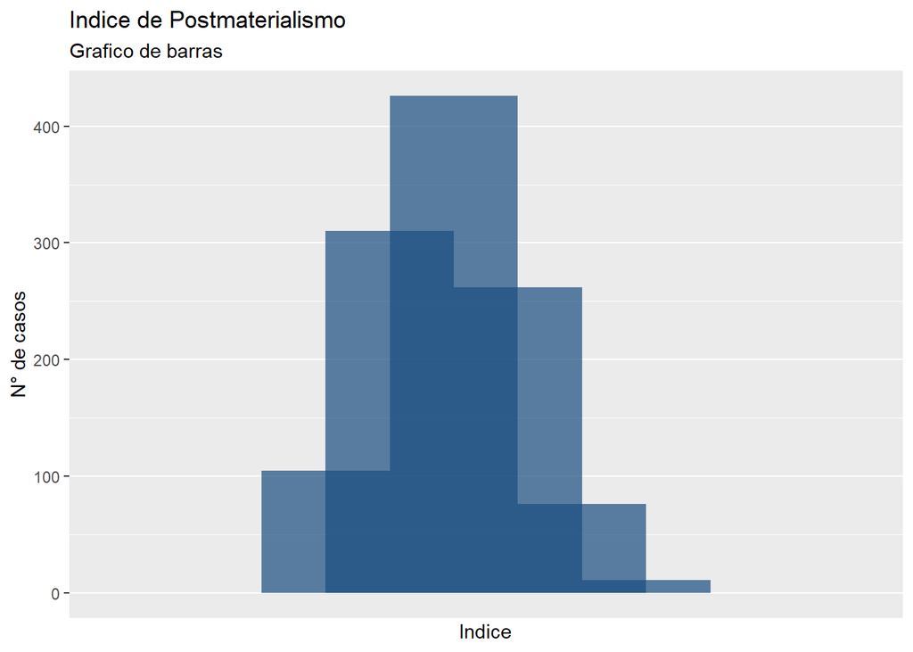

**Estadisticos descriptivos**

| Statistic | N | Mean | St. Dev. | Min | Pctl(25) | Pctl(75) | Max |
| --- | --- | --- | --- | --- | --- | --- | --- |
| Postmaterialismo | 1,190 | 0.4 | 0.2 | 0.0 | 0.2 | 0.6 | 1.0 |

.

#### Gráfico y estadísticos descriptivos del postamaterislismo según el sexo

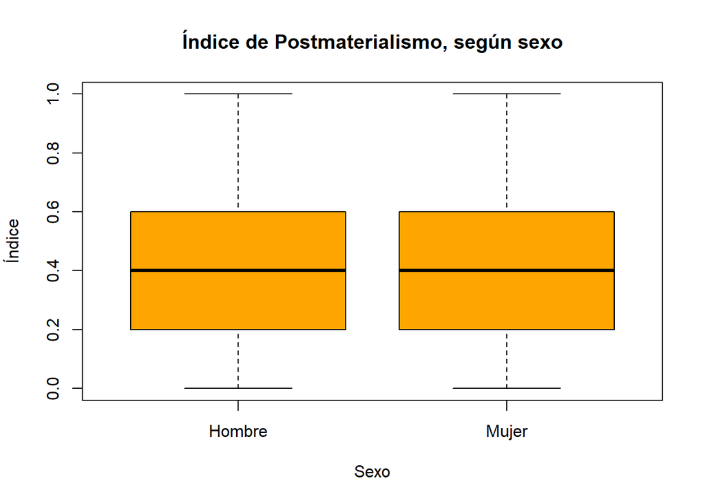

Postmaterislismo según sexo

| Sex | Media | Minimo | Maximo | Diferencia | Desviacion |
| --- | --- | --- | --- | --- | --- |
| Mujer | 0.384 | 0 | 1 | 1 | 0.230 |
| Hombre | 0.391 | 0 | 1 | 1 | 0.202 |

.

Sobre la relación entre la variable sexo y el postmaterialismo se observa de manera descriptiva, como ha sido tendencia durante lo analizado, que existen similitudes importantes entre ambos sexos, con un promedio compartido de casi 0.4. En ese sentido, se puede decir que los dos grupos presentan inclinaciones por valores que se relacionan más con la seguridad material, como ya se mencionó anteriormente. Lo que denotaría que las personas encuestadas poseen objetivos prioritarios similares y que las experiencias sociales diferenciadas de género no tendrían un efecto notable en las preferencias de ambos sexos.

#### Gráfico y estadísticos descriptivos del postamaterislismo según la clase social

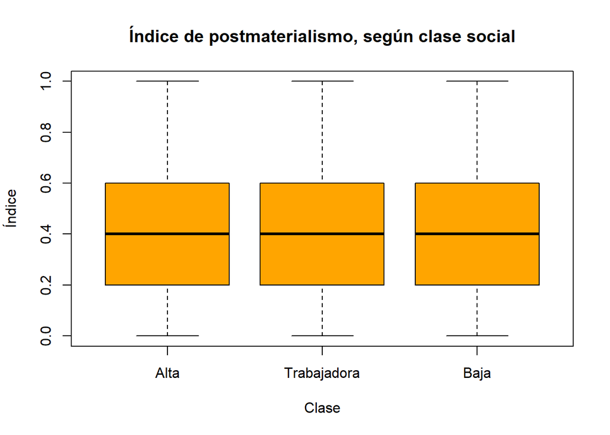

Postmaterislismo según clase social

| Clases | Media | Minimo | Maximo | Diferencia | Desviacion |
| --- | --- | --- | --- | --- | --- |
| Baja | 0.374 | 0 | 1 | 1 | 0.222 |
| Trabajadora | 0.392 | 0 | 1 | 1 | 0.215 |
| Alta | 0.400 | 0 | 1 | 1 | 0.210 |

.

Sobre el postmaterislismo en relación a la clase social, se puede apreciar que las diferencias, nuevamente, no so marcadas; sin embargo, se observa que se rompe esa relación anti-intuitiva descrita líneas arriba, ya que la clase alta es la que tiene un mayor grado de postmaterialismo y ese valor desciente según se “retrocede” en las clases. Sin embargo, ningún grupo realmente puede denominarse como postmaterialismo, ya que ninguno se encuentra cerca de puntaje medio del índice y mucho menos lo supera.

#### Gráfico y estadísticos descriptivos del postamaterislismo según el nivel educativo

[figure not shown]

Postmaterislismo según nivel educativo

| NEDU | Media | Minimo | Maximo | Diferencia | Desviacion |
| --- | --- | --- | --- | --- | --- |
| Superior Completa | 0.312 | 0.0 | 0.8 | 0.8 | 0.219 |
| Maestria/Doctorado | 0.360 | 0.2 | 0.6 | 0.4 | 0.167 |
| Secundaria Completa | 0.362 | 0.0 | 1.0 | 1.0 | 0.202 |
| Primaria completa | 0.383 | 0.0 | 1.0 | 1.0 | 0.218 |
| Sin instruccion | 0.406 | 0.0 | 1.0 | 1.0 | 0.218 |

.

Sobre el grado de postmaterialismo según el nivel educativo se puede observar que la mayoría de los encuestados muestra un bajo nivel de postmaterialismo, una tendencia permanente entre las demás variables. Cabe resaltar que es el grupo sin instrucción el que muestra una mayor tendencia “positiva”, sin embargo, esta es bastante pequeña.

#### Gráfico y estadísticos descriptivos del postamaterislismo según el índice de tradicionalismo

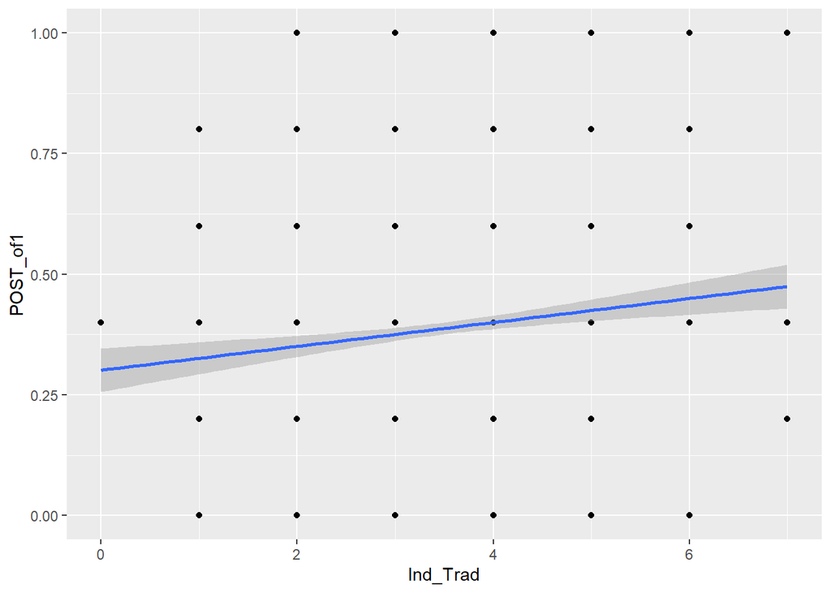

Test de correlación

```
##            POST_of1 Ind_Trad1
## POST_of1  1.0000000 0.1057938
## Ind_Trad1 0.1057938 1.0000000
```

.

Sobre el la relación del postmaterislismo y el indice de tradicionalismo se observa que no parece haber una relación fuerte entre ambas variables, aunque en el gráfico no se aprecia bien, si revisamos la prueba de correlación esta es muy débil. Esta observación será discutida posteriormente.

**Discusión:**

Sobre todo lo revisado descriptivamente hasta ahora cabe resaltar que, de manera general, existen medidas sumamente similares entre los grupos y la relación con la variable independiente principal es sumamente reducida. Estas características son fundamentales para el anális del modelo (y sus variaciones) y la discusión entorno a los resultados que se mostrarán en la siguiente sección.

## SECCIÓN E: Modelos

### Modelo Original:

$$PM_1=B_0+B_1*Trad+B_2*Clase+B_3*NivelEdu+B_4*Genero+B_5(Trad*Clase)+B_6(Trad*NivelEdu)+e$$

- PM_1: índice de postmaterialismo (inclusivo)
- B0: Intersección
- Trad: Tradicionalismo
- Clase:Clase social
- NivelEdu: Nivel Educativo
- Genero:Género
- e: Error

El primer modelo del trabajo, el planteado inicialmente, establecía una relación entre el tradicionalismo y el postmaterialismo, hipótesis general del planteamiento de Ingenhart; sin embargo, el efecto marginal de dicha relación iba a hallarse en función (dependiendo) del nivel educativo y la clase social. Adicionalmente, me interesaba observar las diferecias entre los sexos. Cabe resaltar que para este modelo de usó la primera medición de Postmaterislismo (la inclusiva).

Al correr el modelo de regresión estos son los resultados:

|  | *Dependent variable:* |
| --- | --- |
|  | Postmaterialismo (inclusivo) |
| Tradicionalismo | 0.230** |
|  | (0.107) |
| Educación | -0.010 |
|  | (0.020) |
| Clase | -0.010 |
|  | (0.024) |
| Sexo | -0.008 |
|  | (0.009) |
| Clase*Trad | -0.019 |
|  | (0.046) |
| NivelEdu*Trad | -0.027 |
|  | (0.040) |
| Constant | 0.438*** |
|  | (0.057) |
| Observations | 1,188 |
| R<sup>2</sup> | 0.051 |
| Adjusted R<sup>2</sup> | 0.046 |
| Residual Std. Error | 0.155 (df = 1181) |
| F Statistic | 10.526*** (df = 6; 1181) |
| *Note:* | p<0.1; p<0.05; p<0.01 |

.

**Supuesto 1: No multicolinealidad**

| Observations | 1188 (2 missing obs. deleted) |
| --- | --- |
| Dependent variable | PostMT1 |
| Type | OLS linear regression |

| F(6,1181) | 10.53 |
| --- | --- |
| R² | 0.05 |
| Adj. R² | 0.05 |

|  | Est. | S.E. | t val. | p | VIF |
| --- | --- | --- | --- | --- | --- |
| (Intercept) | 0.44 | 0.06 | 7.63 | 0.00 | NA |
| Ind_Trad1 | 0.23 | 0.11 | 2.16 | 0.03 | 11.22 |
| Educacion | -0.01 | 0.02 | -0.52 | 0.61 | 13.61 |
| Clase | -0.01 | 0.02 | -0.41 | 0.68 | 13.33 |
| Sexo | -0.01 | 0.01 | -0.91 | 0.36 | 1.00 |
| clase_trad | -0.02 | 0.05 | -0.40 | 0.69 | 23.23 |
| nedu_trad | -0.03 | 0.04 | -0.67 | 0.50 | 13.94 |

Standard errors: OLS

Como se observa en la prueba VIF, hay un problema importante de multicolineadlidad, es decir,las variables independientes del modelo original están fuertemente relacionadas; sin embargo, eso es una consecuencia esperable de plantear interacciones, porque, como es evidente, las interacciones son la conjugación de dos variable independientes dentro del modelo. Esto se hace más evidente si observamos que el sexo, la única variable que no es incluida dentro de una interacción, muestra unn nivel normal de VIF. Sin embargo, es importante sañalar que la multicolinealidad al afectar los coeficientes del modelo, lo cual altera su signficancia, impide que se pueda realizar una inferencia estadística confiable. Esto más aún con un nivel alto de VIF en la única variable significativa del modelo, el tradicionalismo.

**Supuesto 2: No heterocedasticidad**

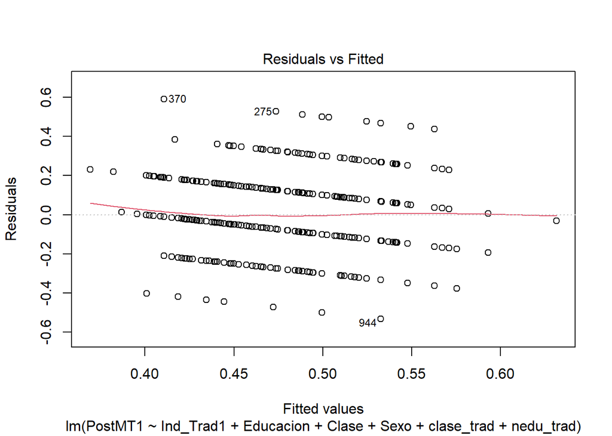

```
##
##  studentized Breusch-Pagan test
##
## data:  modelo_p
## BP = 8.0536, df = 6, p-value = 0.2342
```

.

Sobre el segundo supuesto, se observa que los residuos, frente a los valores ajustados (predichos) por el modelo, tienen una distribución aleatoria en torno a cero, manteniendo aproximadamente la misma variabilidad a lo largo del eje X, es decir tienen errores de estimación constantes. Adicionalmente la prueba de Breusch -Pagan indica que se puede aceptar la H0, es decir, hay homocedasticidad (variación de errores constantes), ya que el p-value es 0.23, valor mayor a 0.05.

**Supuesto 3: Normalidad de residuos**

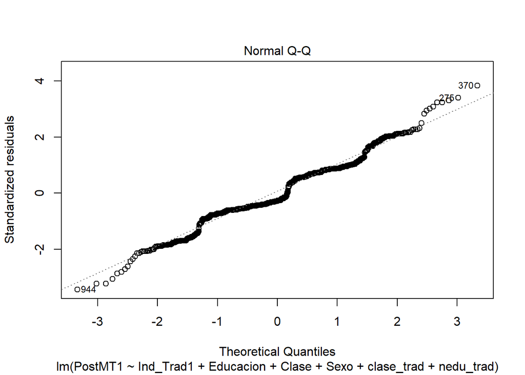

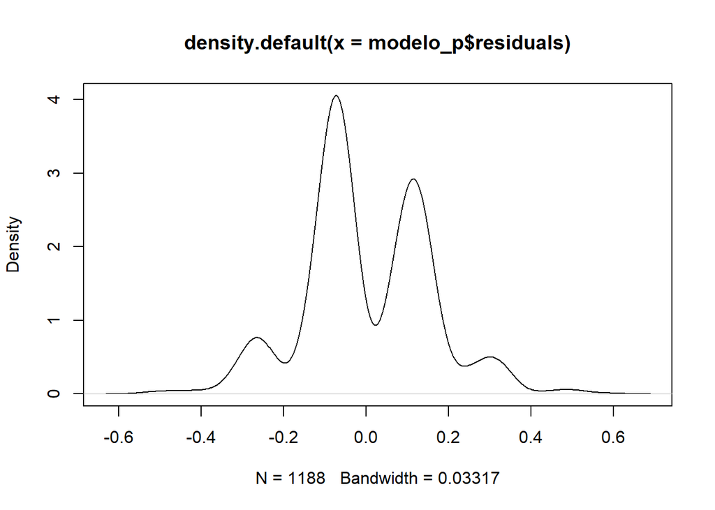

```
##
##  Shapiro-Wilk normality test
##
## data:  modelo_p$residuals
## W = 0.97019, p-value = 6.397e-15
```

Acerca de la normalidad de los residuos se puede concluir, mediante la obervación del gráfico y la prueba de Shapiro-Wilk que este modelo no presenta residuos normales, es decir, la diferecia entre los valores estimados por el modelo y los valores reales de la muestra se diferencian significativamente. Producto de esto la signifancia y los intervalos de confianza no son precisos. Este problema es propio del planteamiento del modelo, porque si revisamos la presencia de valores extremos (influyentes) que podrían estar afectando la normalidad de los residuos no se observan demasiados casos que puedan influir en la diferencia de los valores estimados y los valores de la muestra (se apreciarían esos casos a los extros superior e inferior del siguiente gráfico).

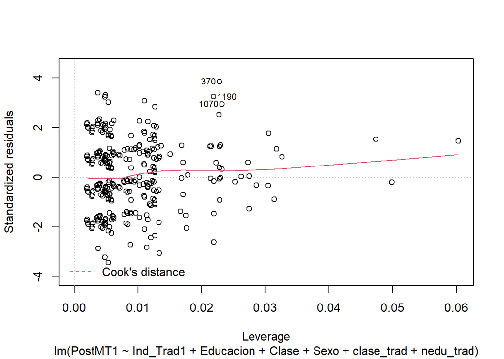

.

En síntesis, luego revisar el cumplimiento de los supuestos, el modelo original no se puede utilizar para hacer inferencias estadísticas sobre el postmaterialismo en función del tradicionalismo. Sin embargo, se realizarán algunas modificaciones para mejorar el modelo o plantear alternativas de solución a este modelo original fallido.

Ahora bien una cuestión importante a mencionar es que este primer modelo si presentaba un nivel de signficancia, aunque poco confiable como ya revisamos; sin embargo, puede que esa significancia y algunos de los problemas posteriores se deban a la construcción de la variable dependiente. El primer índice de postmaterialismo, el inclusivo,contenía variables que podrían verse relacionadas con las variables que componen el índice de tradicionalismo, por ejemplo, la justificación del aborto (componente del ind. de tradicionalismo) y la justificación de la homosexualidad (componente del ind. de postmaterislismo), la importancia de la democracia (postmat.) y el respeto a la autoridad o el sentimiento de orgullo nacional (tradci.). Esta sospecha se puede confirmar si corremos el mismo modelo pero con la variable Y, el postmaterialismo, usando el segundo índice, el exclusivo (solo objetivos).

|  | *Dependent variable:* |
| --- | --- |
|  | Postmaterialismo (exclusivo) |
| Tradicionalismo | 0.015 |
|  | (0.147) |
| Educación | 0.003 |
|  | (0.028) |
| Clase | -0.055 |
|  | (0.033) |
| Sexo | -0.010 |
|  | (0.012) |
| Clase*Trad | 0.087 |
|  | (0.064) |
| NivelEdu*Trad | -0.052 |
|  | (0.056) |
| Constant | 0.436*** |
|  | (0.079) |
| Observations | 1,188 |
| R<sup>2</sup> | 0.024 |
| Adjusted R<sup>2</sup> | 0.019 |
| Residual Std. Error | 0.214 (df = 1181) |
| F Statistic | 4.805*** (df = 6; 1181) |
| *Note:* | p<0.1; p<0.05; p<0.01 |

En ese sentido lo que puede estar pasando dentro del modelo original es que la significancia se construyó a partir de la relación entre las variables “adicionales” que posee el índice de postmaterialismo inclusivo, mientras que en el segundo modelo, el que considera el postmaterislismo solo en función de objetivos, esa correlación deparece.A partir de lo mencionado se puede plantear un modelo “desagregado” en el que se usen las variables adicionales del primer índice de postmaterialismo para ver si estás tienen alguna relación con los ojetivos (segundo ind. de postmaterialismo) y no en relación con los valores tradicionalistas.

### Modelo desagregado

$$PM_2=B_0+B_1*Trad+ B_2*NivelEdu+B_3*Clase+B_4*Genero+ B_5*Fel+B_6*JustHomo+B_7*Demo+B_8* Confianza+ e$$

- PM_2: índice de postmaterialismo (exclusivo)
- B0: Intersección
- Trad: Tradicionalismo
- NivelEdu: Nivel educativo
- Clase:Clase social
- Genero:Género

[Los siguientes son los componentes adicionales del primer índice de postmaterialismo] - Fel: Sentimiento de felicidad - JustHomo: Justificación de la homosexualidad - Demo: Importancia de la democracia - Confiaza: Confianza interpersonal - e: Error

|  | *Dependent variable:* |
| --- | --- |
|  | Postmaterialismo (exclusivo) |
| Tradicionalismo | 0.169*** |
|  | (0.045) |
| Educación | -0.023*** |
|  | (0.008) |
| Clase | -0.013 |
|  | (0.009) |
| Sexo | -0.011 |
|  | (0.012) |
| Felicidad | -0.011 |
|  | (0.009) |
| Just. Homosexualida | -0.001 |
|  | (0.003) |
| Impt.Democracia | -0.004 |
|  | (0.003) |
| Confianza | 0.007 |
|  | (0.029) |
| Constant | 0.424*** |
|  | (0.078) |
| Observations | 1,188 |
| R<sup>2</sup> | 0.025 |
| Adjusted R<sup>2</sup> | 0.018 |
| Residual Std. Error | 0.214 (df = 1179) |
| F Statistic | 3.736*** (df = 8; 1179) |
| *Note:* | p<0.1; p<0.05; p<0.01 |

.

Se observa en el modelo desagreagado que el índice de tradicionalismo tiene tiene una correlación con el indice de postmaterialismo exclusivo, luego de que se eliminaran las interacciones, es decir, es posible que el efecto del tradicionalismo sobre los objetivos postmaterialismos no se encuentren mediados por otra variable, sino que se trate de una relación directa. Además de observa que el nivel educativo también tiene una correlación con la variable dependiente. Sin embargo, todas las demás variables, las adicionales y las anteriormente planteadas, sexo y clase, no tienen una influencia significativa.

Si revisamos, ahora bien si revisamos los supuestos podemos ver que el problema de multicolinealidad se resolvió, posiblemente porque eliminamos las interacciones.

| Observations | 1188 (2 missing obs. deleted) |
| --- | --- |
| Dependent variable | POST_of1 |
| Type | OLS linear regression |

| F(8,1179) | 3.74 |
| --- | --- |
| R² | 0.02 |
| Adj. R² | 0.02 |

|  | Est. | S.E. | t val. | p | VIF |
| --- | --- | --- | --- | --- | --- |
| (Intercept) | 0.42 | 0.08 | 5.41 | 0.00 | NA |
| Ind_Trad1 | 0.17 | 0.05 | 3.75 | 0.00 | 1.05 |
| Educacion | -0.02 | 0.01 | -2.98 | 0.00 | 1.03 |
| Clase | -0.01 | 0.01 | -1.43 | 0.15 | 1.02 |
| Sexo | -0.01 | 0.01 | -0.84 | 0.40 | 1.01 |
| Feliz | -0.01 | 0.01 | -1.27 | 0.20 | 1.03 |
| Q182 | -0.00 | 0.00 | -0.53 | 0.59 | 1.04 |
| Q250 | -0.00 | 0.00 | -1.14 | 0.25 | 1.01 |
| Q57 | 0.01 | 0.03 | 0.24 | 0.81 | 1.01 |

Standard errors: OLS

Sin embargo, aparecen nuevos problemas, no presentes en el modelo anterior.

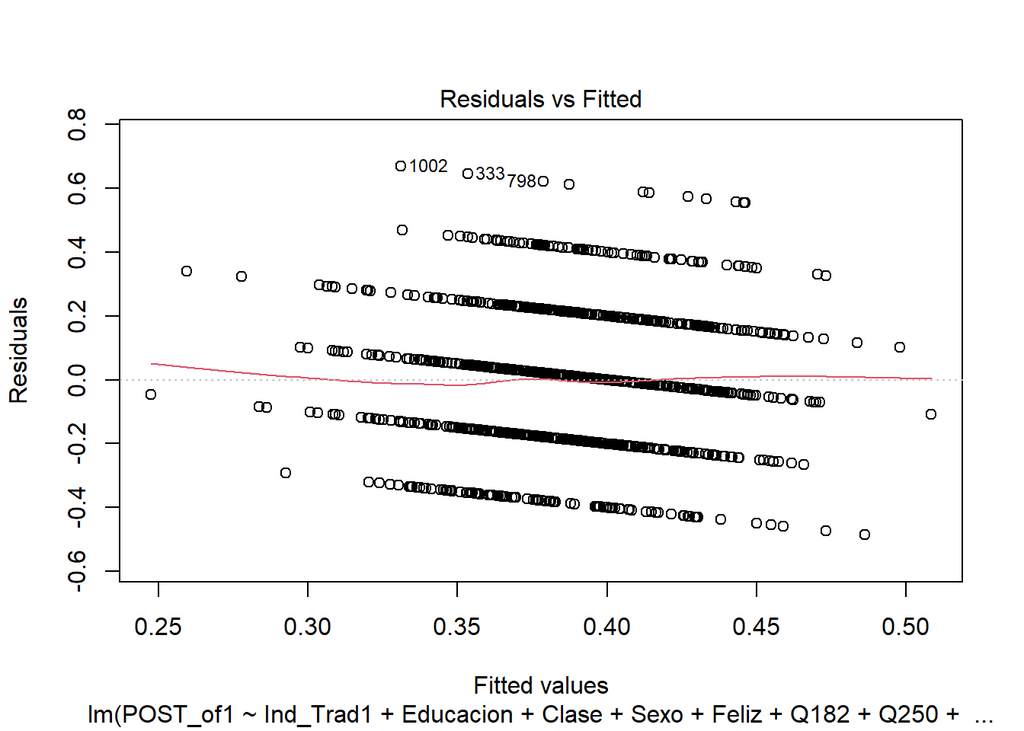

```
##
##  studentized Breusch-Pagan test
##
## data:  modelo50
## BP = 18.758, df = 8, p-value = 0.01621
```

.

Como se observa existe un problema de heterocedasticidad que se podría solucionar con la utilización de errores estandar robustos, como se plantea a continuación:

|  | *Dependent variable:* |
| --- | --- |
|  | Postmaterialismo (exclusivo)[RB] |
| Tradicionalismo | 0.178*** |
|  | (0.051) |
| Educación | -0.022*** |
|  | (0.008) |
| Clase | -0.015 |
|  | (0.010) |
| Sexo | -0.010 |
|  | (0.013) |
| Felicidad | -0.013 |
|  | (0.010) |
| Just. Homosexualida | -0.002 |
|  | (0.003) |
| Impt.Democracia | -0.004 |
|  | (0.004) |
| Confianza | -0.003 |
|  | (0.031) |
| Constant | 0.449*** |
|  | (0.081) |
| Observations | 1,188 |
| R<sup>2</sup> | 0.026 |
| Adjusted R<sup>2</sup> | 0.019 |
| Residual Std. Error | 0.218 (df = 1179) |
| *Note:* | p<0.1; p<0.05; p<0.01 |

```
##
##  studentized Breusch-Pagan test
##
## data:  modelo50_rob
## BP = 18.758, df = 8, p-value = 0.01621
```

Incluso con la aplicación de errores estándar robustos el problema de heterocedasticidad se mantiene; sin embargo, no es tan grave, ya que el p-value se encuentra cerca al 0.05, en ese sentido, se podría aceptar ese problema y continuar con los cálculos. Sin embargo, que que el modelo este sobre-especificado pueden generar problemas como los errores estándar inflados, lo cual efectivamente sucede en este modelo.

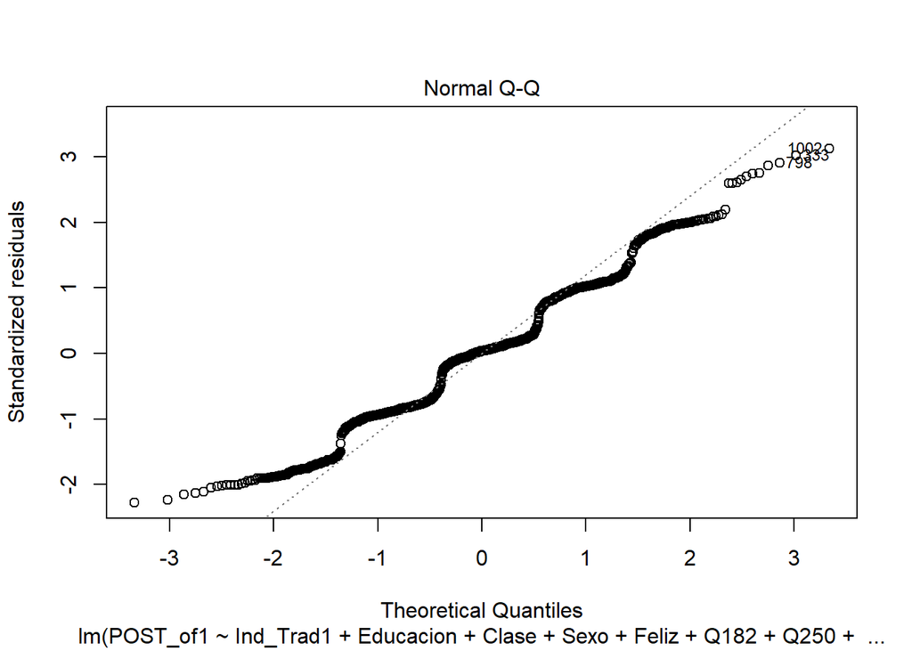

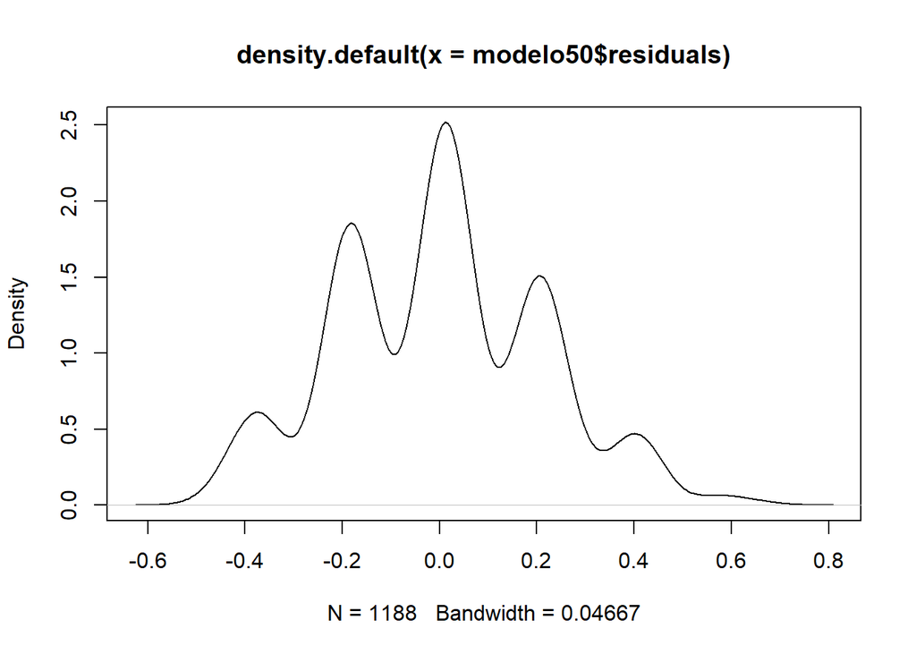

```
##
##  Shapiro-Wilk normality test
##
## data:  modelo50$residuals
## W = 0.97984, p-value = 8.322e-12
```

Antes los problemas señalados de este modelo una última opción puede ser la utilización de solo las variables explicativas que se han mantenido significativas, en este caso el tradicionalismo y el nivel educativo. Evidentemente ese criterio de elección no es el adecuado y se problematizará más adelante; sin embargo, con la finalidad de discutir el efecto del tradicionalismo en el postmaterialismo, cuestión fundamental dentro de la teoría del cambio cultural, así como la capacidad de predicción de la tradicionalismo sobre la VD, vale la pena correr este modelo y analizar los resultados, mencionando, necesariamente, los problemas del criterio de selección y desempeño del modelo.

### Modelo reducido:

$$PM_2=B_0+B_1*Trad+ B_2*NivelEdu+e$$

- PM_2: índice de postmaterialismo (exclusivo)
- B0: Intersección
- Trad: Tradicionalismo
- NivelEdu: Nivel educativo
- e: Error

|  | *Dependent variable:* |
| --- | --- |
|  | Postmaterialismo (exclusivo) |
| Tradicionalismo | 0.163*** |
|  | (0.044) |
| Educación | -0.022*** |
|  | (0.008) |
| Constant | 0.323*** |
|  | (0.024) |
| Observations | 1,188 |
| R<sup>2</sup> | 0.020 |
| Adjusted R<sup>2</sup> | 0.018 |
| Residual Std. Error | 0.214 (df = 1185) |
| F Statistic | 12.047*** (df = 2; 1185) |
| *Note:* | p<0.1; p<0.05; p<0.01 |

.

| Observations | 1188 (2 missing obs. deleted) |
| --- | --- |
| Dependent variable | POST_of1 |
| Type | OLS linear regression |

| F(2,1185) | 12.05 |
| --- | --- |
| R² | 0.02 |
| Adj. R² | 0.02 |

|  | Est. | S.E. | t val. | p | VIF |
| --- | --- | --- | --- | --- | --- |
| (Intercept) | 0.32 | 0.02 | 13.46 | 0.00 | NA |
| Ind_Trad1 | 0.16 | 0.04 | 3.70 | 0.00 | 1.01 |
| Educacion | -0.02 | 0.01 | -2.93 | 0.00 | 1.01 |

Standard errors: OLS

El modelo reducido no presenta problemas de multicolinealidad, algo esperable en un modelo más simple con variables independientes que de forma obvia no están correlacionadas.

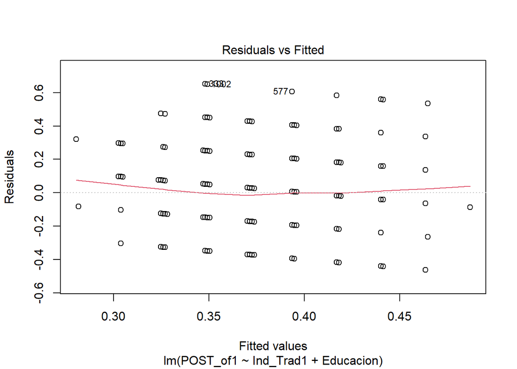

```
##
##  studentized Breusch-Pagan test
##
## data:  modeloz
## BP = 0.80006, df = 2, p-value = 0.6703
```

Tampoco se observan problemas de heterocedasticidad

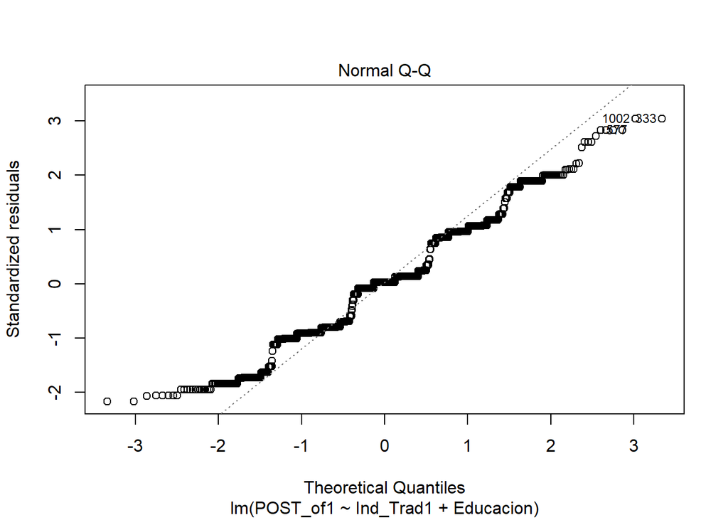

```
##
##  Shapiro-Wilk normality test
##
## data:  modeloz$residuals
## W = 0.97449, p-value = 1.251e-13
```

Sin embargo, como se ha visto a lo largo de las diferentes transformaciones la no hay normalidad de residuos en este modelo tampoco.

Para este último modelo cabe resaltar se usó un criterio de elección modelo “stepwise”, con dirección backward, es decir, modelo se inició con todas las variables disponibles incluidas como predictores, como se hizo para el modelo desagregado. Se probó eliminar las variables no significativas hasta quedarme con las variables que sí mostraron alguna correlación. Aunque este método permite evaluar cada variable en presencia de las otras, este criterio de selección tiene el potencial problema de hacer en un error de tipo I (H0 es verdadera, pero se le concibe como falsa), porque la eliminación de los predictores menos significativos tiende a incrementar la significancia de los otros predictores. Así, se trata de un modelo muy simple, potencialmente sesgado,con una capacidad de predictibilidad muy baja.

Finalmente, antes de discutir el modelo que se podría utilizar para discutir el efecto del tradicionalismo en el postmaterialismo, es importante señalar una cuestión no mencionada dentro de la revisión realizada y esta es los posibles problemas de endogeneidad que pueden tener los modelos planteados. Los problemas de endogeneidad se relacionan con que dentro de un modelo el error debe ser el mismo independientemente de los valores que toman las variables independientes, ya que eso significa que estas no se relacionan con el error. Así, cuando una variable independiente es endógena sus valores están determinados dentro del modelo y es exógena cuando sus valores se determinan fuera del modelo; las variables endógenas se asocian con el error, mientras que las exógenas son medidas sin error.

Así,si revisamos las fuentes de endogeneidad de los modelos, en relación al primera fuente, de variable omitida, esta es la más peligrosa dentro de los modelos. Hay muchas cuestiones que pueden influir en el tradicionalismo, por ejemplo, el nivel de ingresos o el área de residencia son potenciales variables relevantes, por ejemplo, con respecto a la última variable mencionada el sentimiento de orgullo nacional, cuestión importante para determinar el grado de tradicionalismo, se puede relacionar con las experiencias de atención estatas o el centralismo de modo que una parte del tradicionalismo se explicaría desde esta variable y al ignorarla se incrementa el error, entonces la variable de tradicionalismo va a variar en relación a esa variable, por lo tanto tendríamos un beta1 (coeficiente) sesgado.

Sobre la segunda fuente de endogeneidad, la cual es la que más se podría discutir, es la de error de medición. Si bien para el trabajo se realizaron algunas transformaciones en la construcción del índice de tradicionalismo, aún se podrían plantear observaciones. Por ejemplo, sobre la importancia de Dios en la vida, se podría optar por continuar con la utilización del la importancia de la fe por sobre la ciencia, pero además agregar las prácticas religiosas (asistir a misa) para construir dicho indicador porque quedaría más precisa la construcción de lo que se pretende medir. Adicionalmente, se podría replantear la fe religiosa como un determinante del tradicionalismo, pues según las investigaciones de Catalina Romera, muchas veces la religión se asocia más con valores que impulsan la libertad y la autodeterminación. Por otro lado, en lugar de usar la justificación del aborto se podría optar por preguntar sobre la autonomía que posee la mujer con su cuerpo, así el encuestado podría pensar su posición sobre la igualdad de género más allá de si está o no de acuerdo con el aborto.

Finalmente sobre la última fuente, la causalidad inversa, es dificil plantear un escenario en que el tradicionalismo se explique desde el postmaterialismo, pues si seguimos una línea lógica, primero están las condiciones objetivas de existencia (como el nivel educativo, la clase, el sexo), luego las creencias (los valores tradicionales seculares o tradicioanales) y, por último, las expectativas, objetivos, demandas que una persona puede tener (el postmaterialismo)

Ahora bien, como discursión final, podemos ver el grado de influencia que tiene el tradicionalismo dentro del posmaterialismo, dentro de los modelos que mostraron algún grado de correlación (significancia).

|  | *Dependent variable:* |  |  |
| --- | --- | --- | --- |
|  | Postmaterialismo (inclusivo) | Postmaterialismo(exclusivo |  |
|  | *OLS* | *MM-type* |  |
|  |  | *linear* |  |
|  | (1) | (2) | (3) |
| Tradicionalismo | 0.230** | 0.178*** | 0.175*** |
|  | (0.107) | (0.051) | (0.050) |
| Educación | -0.010 | -0.022*** | -0.021*** |
|  | (0.020) | (0.008) | (0.008) |
| Clase | -0.010 | -0.015 |  |
|  | (0.024) | (0.010) |  |
| Sexo | -0.008 | -0.010 |  |
|  | (0.009) | (0.013) |  |
| Clase*Trad | -0.019 |  |  |
|  | (0.046) |  |  |
| NivelEdu*Trad | -0.027 |  |  |
|  | (0.040) |  |  |
| Felicidad |  | -0.013 |  |
|  |  | (0.010) |  |
| Just. Homosexualida |  | -0.002 |  |
|  |  | (0.003) |  |
| Impt.Democracia |  | -0.004 |  |
|  |  | (0.004) |  |
| Confianza |  | -0.003 |  |
|  |  | (0.031) |  |
| Constant | 0.438*** | 0.449*** | 0.314*** |
|  | (0.057) | (0.081) | (0.027) |
| Observations | 1,188 | 1,188 | 1,188 |
| R<sup>2</sup> | 0.051 | 0.026 | 0.020 |
| Adjusted R<sup>2</sup> | 0.046 | 0.019 | 0.019 |
| Residual Std. Error | 0.155 (df = 1181) | 0.218 (df = 1179) | 0.220 (df = 1185) |
| F Statistic | 10.526*** (df = 6; 1181) |  |  |
| *Note:* | p<0.1; p<0.05; p<0.01 |  |  |

## SECCIÓN F: Observaciones finales

Una cuestión importante de atender antes de concluir el trabajo es señalar que muchos de los problemas observados, más allá de la impresición de la medición de las variables, pueden estar relacionados a las características de la muestra.Como se observó dentro de los gráficos descriptivos muchas categorías de las variables independientes están sobre-representadas y aunque se intentó mitigar el desbalance mediante la conjunción de ciertas categorías, la desigualdad era tanta que era dificil arreglarla. Incluso si se optara por conglomerados, es decir, seleccionar proporcionalmente a los sujetos de cada categoría para que la variable esté balanceada poseer una base de datos bastante pequeña impide realizar esas modificaciones.